# Simple linear regression: categorical predictor (Notes)

STAT 155

Author

Your Name

# Notes

## Learning goals

By the end of this lesson, you should be able to:

- Write a **model formula** for a simple linear regression model with a categorical predictor using **indicator variables**
- Interpret the **intercept** and **slope** coefficients in a simple linear regression model with a categorical predictor

## Readings and videos

Complete *both* the reading and the videos to go through **before** class.

- Reading: Section 3.9 in the [STAT 155 Notes](https://mac-stat.github.io/Stat155Notes/) only up through section 3.9.1 Indicator Variables
- Videos:
  - [Simple linear regression: categorical predictor](https://youtu.be/QPpp6Kpk2To) ([slides](https://drive.google.com/file/d/1fbSJW4DhVWxR8rykowPUoAZ6WfzuZ857/view?usp=sharing))
  - [R Code for Categorical Predictors](https://voicethread.com/share/14980390/)

**File organization:** Save this file in the “Activities” subfolder of your “STAT155” folder.

# Exercises

**Context:** Today we’ll explore data on thousands of diamonds to understand how physical characteristics relate to price. Read in the data below.

```r
# Load packages and import data
library(ggplot2)
library(dplyr)

data(diamonds)

# A little bit of data wrangling code - let's not focus on this for now
diamonds <- diamonds %>%
    mutate(
        cut = factor(cut, ordered = FALSE),
        color = factor(color, ordered = FALSE),
        clarity = factor(clarity, ordered = FALSE)
    )
```

For the first several exercises, our focus will be on the relationship between diamond price and cut.

## Exercise 1: Get to know the data

Write R code to answer the following:

- How many cases and variables do we have? What does a case represent?
- What do the first few rows of the data look like?
- Construct and interpret two different visualizations of the `price` variable.
- Construct and interpret a visualization of the `cut` variable.

## Exercise 2: Visualizations

Start by visualizing this relationship of interest, that between `price` and `cut`.

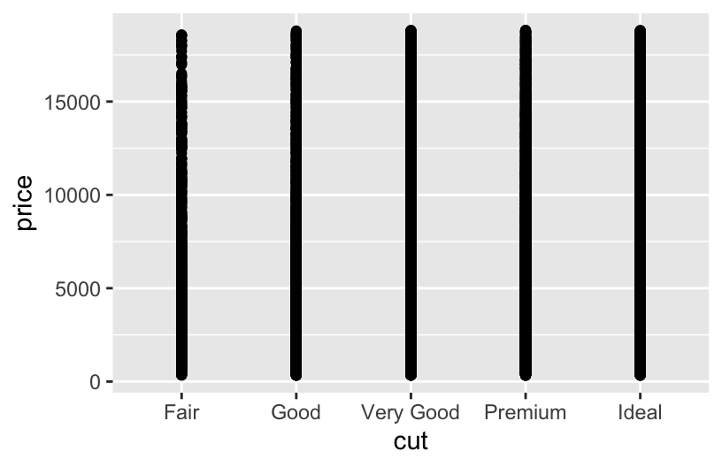

```r
# Try a scatterplot
ggplot(diamonds, aes(y = price, x = cut)) +
    geom_point()
```

2. Separately run each chunk below, with two plots. Comment (`#`) on what changes in the code / output.

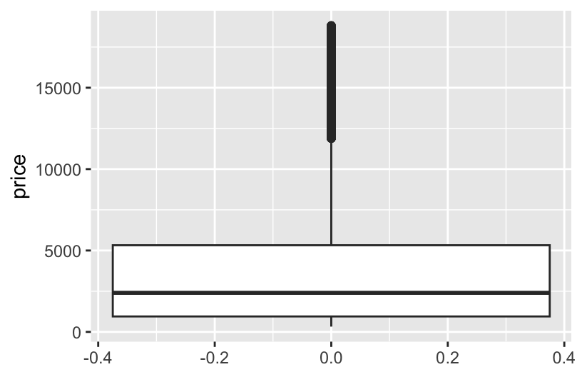

```r
# Univariate boxplot
ggplot(diamonds, aes(y = price)) +
    geom_boxplot()
```

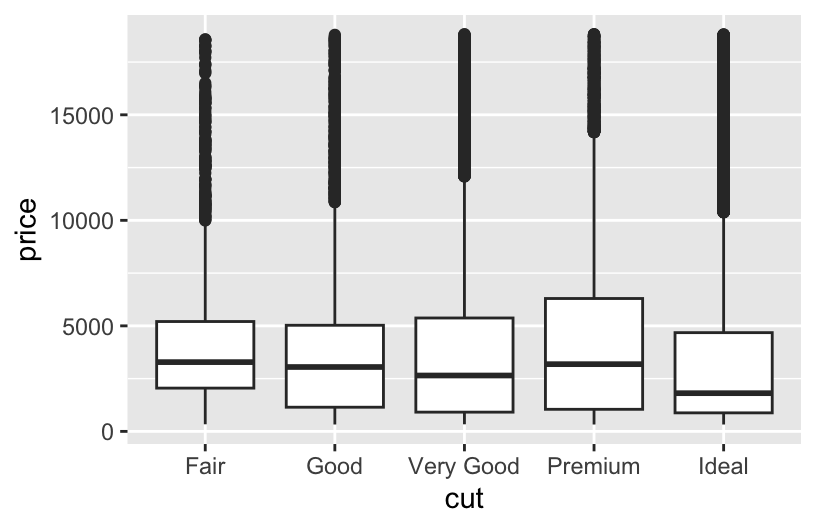

```r
# ???
ggplot(diamonds, aes(y = price, x = cut)) +
    geom_boxplot()
```

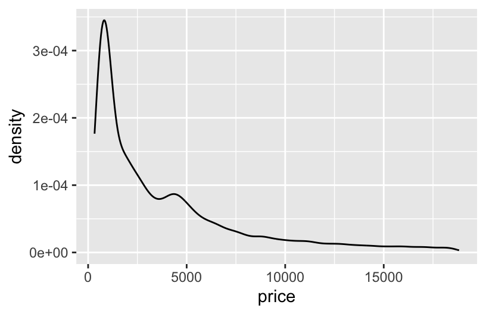

```r
# Univariate density plot
ggplot(diamonds, aes(x = price)) +
    geom_density()
```

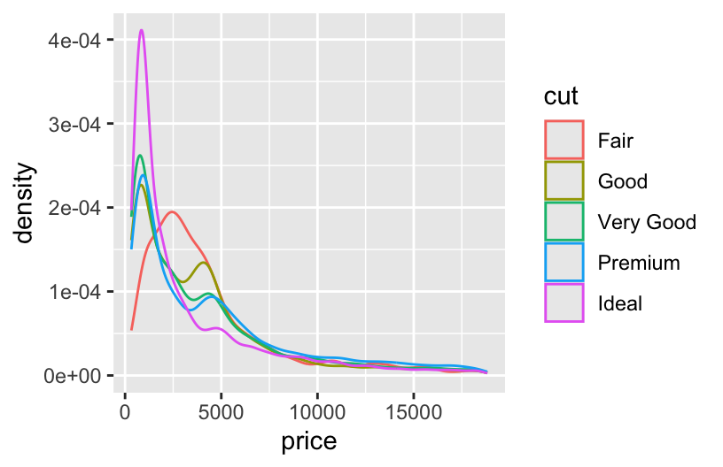

```r
# ???
ggplot(diamonds, aes(x = price, color = cut)) +
    geom_density()
```

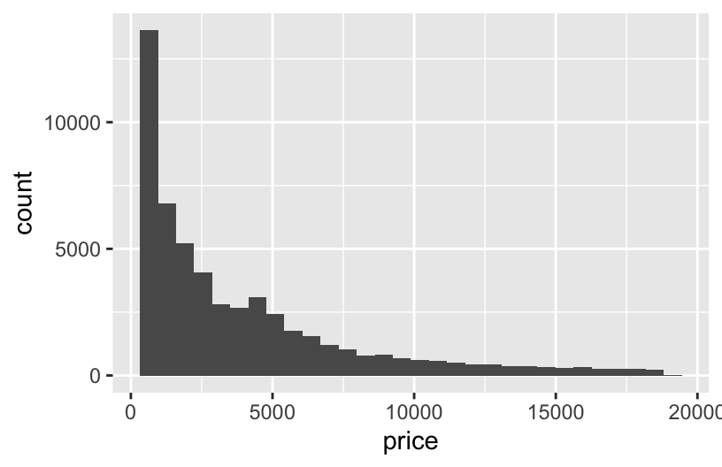

```r
# Univariate histogram
ggplot(diamonds, aes(x = price)) +
    geom_histogram()
```

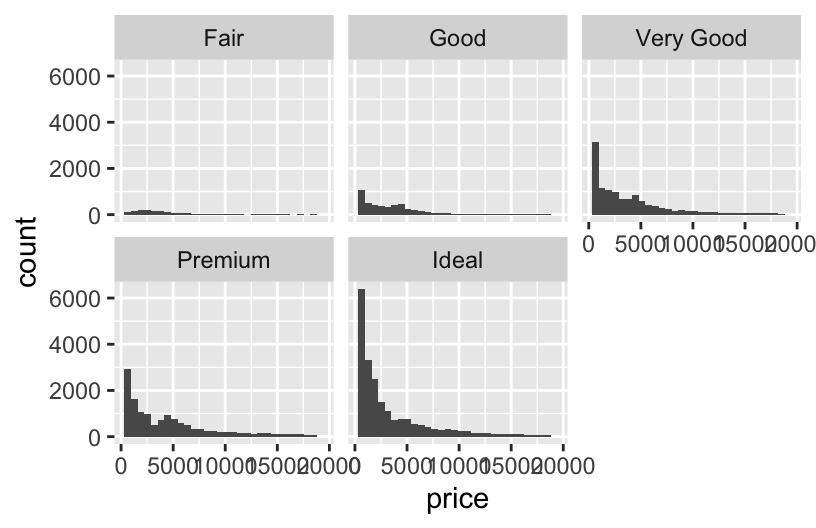

```r
# ???
ggplot(diamonds, aes(x = price)) +
    geom_histogram() +
    facet_wrap(~ cut)
```

3. Do you notice anything interesting about the relationship between price and cut? What do you think might be happening here?